# G&S3-11

Rong Li

2021/2/10

## Assignment Information

This assignment is due on Wednesday Feb 10. Please submit your work by copying the github address for your work and please make sure that your code will run when it is downloaded (include an Rproj file and a README file).

## Problem Background

- Type 1 error: Assume that the $H_0 : p = 0.6$ is true, then if more than $m(m > \mu = np =0.6n)$ people are cured, we reject $H_0$.
  $$P(more\ than\ m\ people\ cured) = \alpha(0.6) = \sum_{m \leq k \leq n}b(n, 0.6, k)\ \hat =\ Type\ 1\ error$$
  We want to choose m so as to make $\alpha(0.6)$ small, to reduce the likelihood of a type 1 error.
- Type 2 error: Assume that the $H_1 : p > 0.6$ is true(the author choose $p = 0.8$ by casual), then if less than $m(m < \mu = np)$ people are cured, we reject $H_1$. We want type 2 error to be small either.
  $$P(less\ than\ m\ people\ cured) = 1 - \alpha(0.8) = 1 - \sum_{m \leq k \leq n}b(n, 0.8, k)\ \hat =\ \beta(0.8) \ =\ Type\ 2\ error$$
  We want to choose m so as to make $\beta(0.8)$ small, to reduce the likelihood of a type 2 error.

## Replicate Figure 3.7

In Figure 3.7, the author set n = 100, plot the $\alpha(p)$ for p ranging from 0.4 to 1. The left line is when m = 69 and right line is when m = 73.

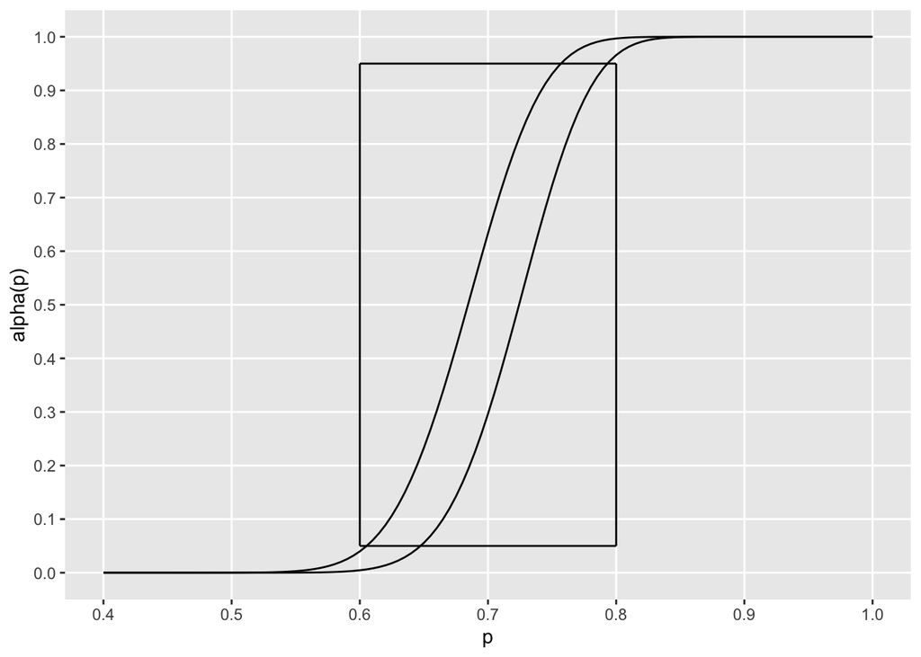

```r
PowerCurve <- function(p,m){
  sum <- 0
  for (i in m:100) sum = sum + dbinom(i, 100, p)
  return(sum)
}

x <- seq(.4, 1, .005)
y1 <- PowerCurve(x, 69)
y2 <- PowerCurve(x, 73)

ggplot() +
  geom_line(mapping = aes(x = x, y = y1)) +
  geom_line(mapping = aes(x = x, y = y2)) +
  scale_x_continuous(limits = c(.4, 1), breaks = seq(.4, 1, .1), minor_breaks = NULL) +
  scale_y_continuous(limits = c(0, 1), breaks = seq(0, 1, .1), minor_breaks = NULL) +
  xlab("p") +
  ylab("alpha(p)") +
  geom_segment(aes(x = 0.6, y = 0.95, xend = 0.8, yend = 0.95)) +
  geom_segment(aes(x = 0.6, y = 0.05, xend = 0.8, yend = 0.05)) +
  geom_segment(aes(x = 0.6, y = 0.05, xend = 0.6, yend = 0.95)) +
  geom_segment(aes(x = 0.8, y = 0.05, xend = 0.8, yend = 0.95))
```

## Explaination

In the problem background, we mentioned that we want to reduce the likelihood of type 1 and type 2 error. The author want our critical number m to make each of these undesirable cases less than 5 percent probable, which means $\alpha_{0.6}(m) < 0.05$ and $\beta_{0.8}(m) = 1- \alpha_{0.8}(m) < 0.05$.  
So that we need $\alpha_{0.6}(m) < 0.05$ and $\alpha_{0.8}(m) > 0.95$

### $\alpha_{0.6}(m) < 0.05$

If we need $\alpha_{0.6}(m) < 0.05$, we first plot the $\alpha_{0.6}(m)$ vs. m.

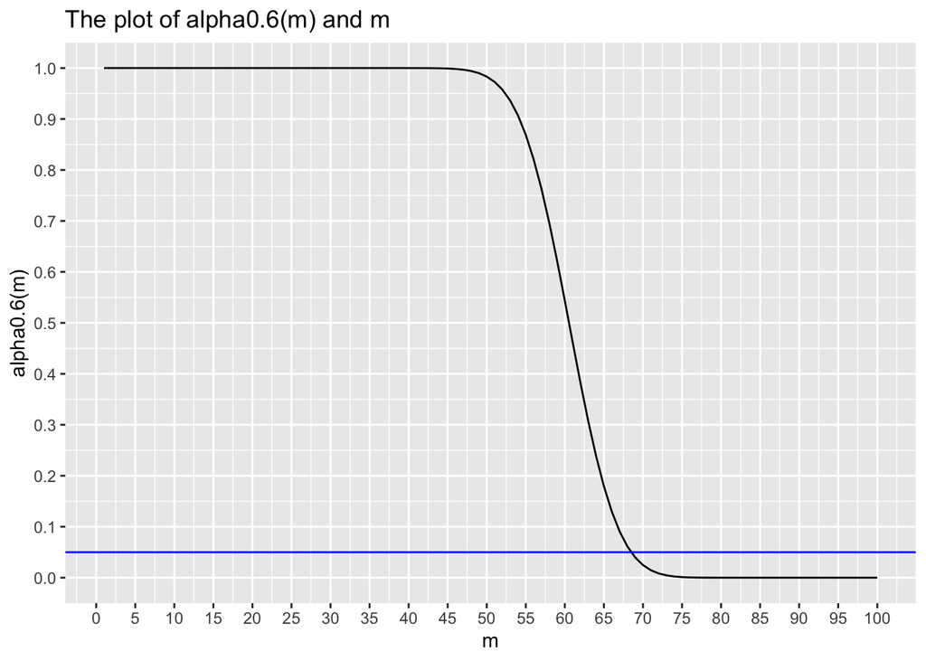

The cutpoint should lie between 65 and 70, we now print the value of $\alpha_{0.6}(m)$.

```
##    m alpha0.6.m.
## 1 65  0.17946935
## 2 66  0.13033653
## 3 67  0.09125360
## 4 68  0.06150391
## 5 69  0.03984788
## 6 70  0.02478282
```

### $\alpha_{0.8}(m) > 0.95$

If we need $\alpha_{0.8}(m) > 0.95$, we first plot the $\alpha_{0.8}(m)$ vs. m.

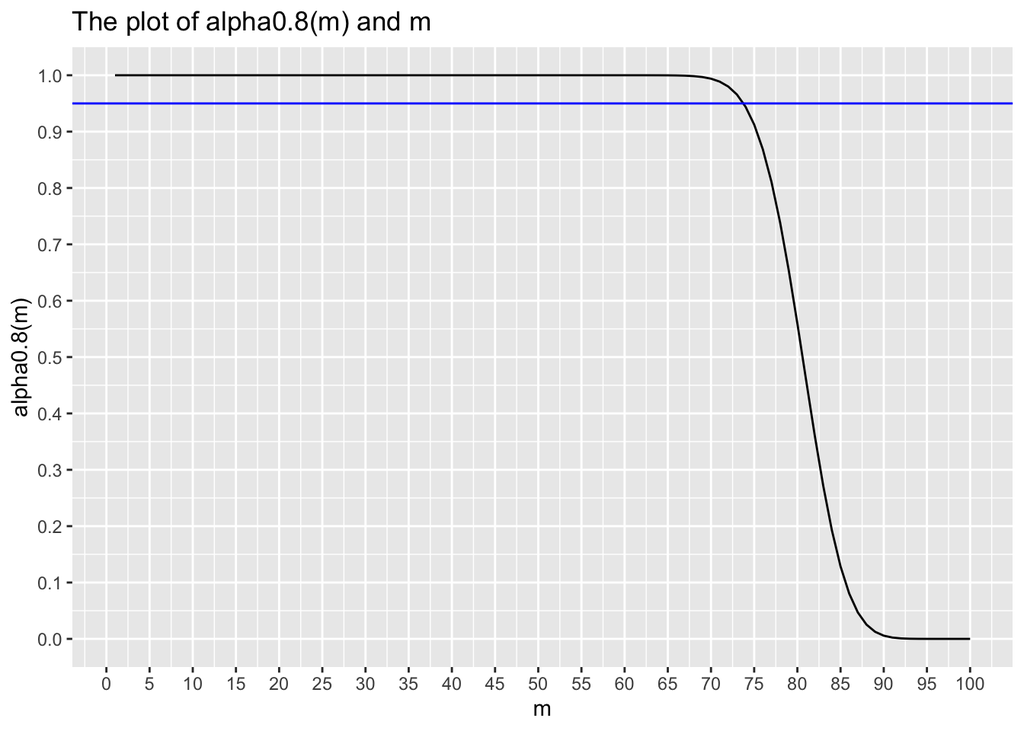

The cutpoint should lie between 70 and 75, we now print the value of $\alpha_{0.8}(m)$.

```
##    m alpha0.8.m.
## 1 70   0.9939407
## 2 71   0.9887510
## 3 72   0.9799798
## 4 73   0.9658484
## 5 74   0.9441673
## 6 75   0.9125246
```

In conclusion, we produce an explanation of the example showing how the authors reached their conclusion that the critical value should be between 69 and 73 people cured.